# Covid Stringency Index in the Philippines

Coronavirus

Asia

Tables

In this post we will explore the covid’19 statistics in Philippines. The total number of cases, deaths, recovery and the total vaccinated so far. Apart from that we will also explore the govenments’ covid stringency index in the Philippines.

Ratul Wadhwa https://github.com/etc5523-2021/blog-ratulwadhwa  
08-30-2021

## Introduction

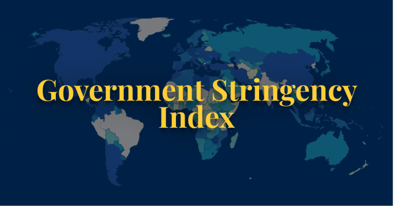

The current ongoing pandemic Coronavirus has affected millions of countries in various ways. To slow the spread of this virus, countries around the world are implementing strict measures, from national lock downs to school closures.

To calculate the intensity of these strict measures, the Oxford Coronavirus Government Response Tracker (OxCGRT) project came up with a **Stringency Index**. Stringency Index is a composite measure of nine of the response metrics.

The nine metrics used to calculate the Stringency Index are: restrictions on public gatherings; restrictions on internal movements; cancellation of public events; closures of public transport; stay-at-home requirements; school closures; international travel controls; workplace closures; and public information campaigns.

The index on any given day is calculated as the mean score of the nine metrics, each taking a value between 0 and 100. In this blog, we will be discussing about the covid’ 19 Stringency Index in the Philippines. In the first part of the blog, we will have a look at the total number of confirmed cases, deaths, recovered and total number of vaccinated people so far in Philippines and in the latte part we shall look at the strictness of government policies with respect to the cases.

## Data Description

In this section we will be looking at the covid’19 statistics in Philippines along with its numerical summary statistics (mean, sd, max cases, min cases). In order to achieve this, I chose the data set from [ourworldindia](https://ourworldindata.org/) which contains information regarding the daily reported confirmed cases, total number of deaths, total vaccinated citizens, daily Stringency Index, etc. I filtered Philippines from the data set in order to get its day to day covid’19 statistics (Hannah Ritchie and Roser (2020)). The data set is updated on a regular basis and contains information till September 2021.

The only limitation of this data set is that it does not contain the recovery status of the citizen, hence to calculate that I used the coronavirus package of R that provides a tidy format data set of the 2019 Novel Krispin and Byrnes (2021) COVID-19 (2019-nCoV) epidemic. The raw data is pulled from the Johns Hopkins University Center for Systems Science and Engineering (JHU CCSE) Coronavirus repository.

## Numerical Summary Statistics

### Covid’19 statistics

Philippines was ranked as one of the top countries in Southeast Asia and 27 out of the 192 countries based on the number of confirmed positive cases. Lets have a look at the below table, table 1 which shows the total number of confirmed cases, tested positive, recovered, deaths and vaccinated people in Philippines.

**Philippines**

Table 1: Covid statistics of Philippines

| Month | Confirmed | Tested | Recovered | Deaths | Vaccinated |
| --- | --- | --- | --- | --- | --- |
| 2020 |  |  |  |  |  |
| 01 | 1 | 0 | 0 | NA | 0 |
| 02 | 2 | 0 | 1 | NA | 0 |
| 03 | 2081 | 0 | 48 | 87 | 0 |
| 04 | 6404 | 78914 | 994 | 480 | 0 |
| 05 | 9598 | 237973 | 2866 | 389 | 0 |
| 06 | 19428 | 360407 | 6324 | 309 | 0 |
| 07 | 55840 | 768793 | 54945 | 757 | 0 |
| 08 | 127465 | 1017208 | 92384 | 1535 | 0 |
| 09 | 90875 | 1072755 | 95926 | 1946 | 0 |
| 10 | 69035 | 1027535 | 77558 | 1717 | 0 |
| 11 | 50901 | 894039 | 67612 | 1171 | 0 |
| 12 | 42434 | 930208 | 41138 | 852 | 0 |
| 2021 |  |  |  |  |  |
| 01 | 51554 | 1012564 | 47755 | 1505 | 0 |
| 02 | 50734 | 906489 | 46720 | 1569 | 0 |
| 03 | 170936 | 1379574 | 69475 | 979 | 145741 |
| 04 | 290172 | 1570653 | 342572 | 3937 | 688736 |
| 05 | 192841 | 1524840 | 185624 | 3732 | 1676968 |
| 06 | 182258 | 1506110 | 0 | 3696 | 2849438 |
| 07 | 176406 | 1528069 | 0 | 3227 | 2122717 |
| 08 | 365058 | 1442761 | 0 | 5220 | 2430632 |

Source: 2020 (JHU CCSE)

### Summary Statistics

|  | Variables | Mean | SD | Maximum | Minimum |
| --- | --- | --- | --- | --- | --- |
| 1 | Confirmed | 97701.15 | 102553.81 | 365058 | 1 |
| 2 | Tested | 862944.6 | 563051.13 | 1570653 | 0 |
| 3 | Recovered | 56597.1 | 82755.5 | 342572 | 0 |
| 4 | Deaths | 1839.33 | 1490.85 | 5220 | 87 |
| 5 | Vaccinated | 495711.6 | 943855.92 | 2849438 | 0 |

The above table 2 shows that the max number of covid cases in Philippines were 365058. The standard deviation of the confirmed cases and vaccinations are higher indicating that the data in these columns are more spread out when compared to the death. It can be seen that the recovery rate is quite good as the mean recovered is quite high in comparison to the mean deaths. Its also satisfying to observe that the maximum vaccinaed number of people is 2849438 which shows that more and more number of people are getting them selves vaccinated.

## Covid Stringency Index

As discussed above, the stringency index on any given day is calculated as the mean score of the nine metrics, each taking a value between 0 and 100. A higher score (i.e. 100 or close to 100) indicates a stricter response where as a low score indicates some ease in the policies and restrictions overall.

Lets have a close look on table 3 to understand the strictness of government policies with respect to the number of total confirmed cases.

[output not shown]

[output cut: 19 more lines]

## Conclusion

According to the above analysis, we can see that with an ease in the restriction by the government, there was quite an increase in the number of cases. As the stringency index decreased from 100 to 96 and further to 77.78 in table 3, the number of cases recorded, started to increase from 173347 to 334494 and 363052 respectively. It can be concluded that Governance arrangements play a critical role in countries’ immediate responses to the spread of virus.

Restrictions on internal movements; cancellation of public events; closures of public transport; stay-at-home requirements; school closures; international travel controls; workplace closures; and public information campaigns are few of the very important measures that Philippines or any other country should not ignore in order to avoid the COVID-19 transmission(Lindo (n.d.)).

Although these restrictions are curbing the spread of Coronavirus, they cannot last indefinitely, at least not without causing enormous damage to economies and compromising peoples’ good will and emotional well-being. Its important that people take precautions, get vaccinated and avoid going outside as much as they can.

*Data sets used for the analysis are: Hannah Ritchie and Roser (2020) Krispin and Byrnes (2021)*

*R packages used for the analysis are: Wickham et al. (2021) Iannone, Cheng, and Schloerke (2021) Wickham et al. (2019) Vaidyanathan, Russell, and Watts (2016) Xie, Cheng, and Tan (2021)*

Hannah Ritchie, Lucas Rodés-Guirao, Edouard Mathieu, and Max Roser. 2020. “Coronavirus Pandemic (COVID-19).” *Our World in Data*.

Iannone, Richard, Joe Cheng, and Barret Schloerke. 2021. *Gt: Easily Create Presentation-Ready Display Tables*. https://CRAN.R-project.org/package=gt.

Krispin, Rami, and Jarrett Byrnes. 2021. *Coronavirus: The 2019 Novel Coronavirus COVID-19 (2019-nCoV) Dataset*. https://CRAN.R-project.org/package=coronavirus.

Lindo, Garry S. n.d. “Exploring Compatibility of Virtual Learning Modalities in Surigao Del Sur State University, Cagwait Campus During the COVID 19 Pandemic.” *Age* 18 (20): 21–24.

Vaidyanathan, Ramnath, Kent Russell, and Gareth Watts. 2016. *Sparkline: ’jQuery’ Sparkline ’Htmlwidget’*. https://CRAN.R-project.org/package=sparkline.

Wickham, Hadley, Mara Averick, Jennifer Bryan, Winston Chang, Lucy D’Agostino McGowan, Romain François, Garrett Grolemund, et al. 2019. “Welcome to the tidyverse.” *Journal of Open Source Software* 4 (43): 1686. https://doi.org/10.21105/joss.01686.

Wickham, Hadley, Romain François, Lionel Henry, and Kirill Müller. 2021. *Dplyr: A Grammar of Data Manipulation*. https://CRAN.R-project.org/package=dplyr.

Xie, Yihui, Joe Cheng, and Xianying Tan. 2021. *DT: A Wrapper of the JavaScript Library ’DataTables’*. https://CRAN.R-project.org/package=DT.